# Lab1

Reesa John

1/16/2019

```r
hiphop <- read.csv("https://raw.githubusercontent.com/kbodwin/STAT-331/master/In-Class%20Activities/Data/hiphop.csv?token=AVHCwRXHTU_HZuxL-Iofhjhi-QqAgfxOks5cSRj-wA%3D%3D")
# Don't forget to remove the spaces in the URL after "STAT-331/" and before "token".
library(tidyverse)
# If you get an error on library(tidyverse), run the line below in your console.
# Do NOT uncomment this line!
# install.packages("tidyverse")
```

**Introduction**

1. Provide a brief overview (2-4 sentences) of the dataset. You may simply reference your work on the Day 2 activity to make this summary. We are repeating this because it is always good practice to start an analysis by getting a feel for the data and providing a quick summary for readers.

This dataset is the results of a survey where 168 subjects were asked to define 64 AAE words. Each subject-word pair had a row on the table. The survey also recorded other data such as each subject’s sex, age, ethnicity, genres of music they like, etc. Some of the categorical variables were converted into discrete or binary variables such as knowledge of Justin Bieber songs (bieber) and is Jay-z married or not (jayz1).

```r
str(hiphop)
```

```
## 'data.frame':    10752 obs. of  38 variables:
##  $ word               : Factor w/ 64 levels "[to be] ghost",..: 1 1 1 1 1 1 1 1 1 1 ...
##  $ subj               : Factor w/ 168 levels "p1","p10","p101",..: 53 126 38 107 19 7 144 8 4 153 ...
##  $ sex                : Factor w/ 2 levels "Female","Male": 1 1 2 1 1 2 1 2 2 2 ...
##  $ age                : int  20 17 41 18 18 19 18 18 19 19 ...
##  $ ethnic             : Factor w/ 9 levels "african","asian",..: 9 9 9 9 9 9 9 9 2 9 ...
##  $ city               : num  33283 34033 8789 712 24280 ...
##  $ county             : num  1156212 396500 58696 148955 153504 ...
##  $ intl               : int  0 0 0 0 0 0 0 0 0 0 ...
##  $ vocal              : int  0 0 2 0 3 0 0 0 0 1 ...
##  $ classical          : int  0 0 0 0 3 0 0 0 0 0 ...
##  $ folk               : int  0 0 0 1 0 0 2 0 0 0 ...
##  $ rock               : int  1 0 0 1 1 0 0 1 0 4 ...
##  $ country            : int  3 1 0 2 0 1 0 3 0 4 ...
##  $ pop                : int  4 3 0 2 3 1 0 1 0 4 ...
```

[output cut: 24 more lines]

```r
summary(hiphop)
```

```
##             word           subj           sex            age
##  [to be] ghost: 168   p1     :   64   Female:7488   Min.   :16.00
##  5-0          : 168   p10    :   64   Male  :3264   1st Qu.:18.00
##  A-town       : 168   p101   :   64                 Median :19.00
##  ashy         : 168   p102   :   64                 Mean   :20.02
##  ay yo trip   : 168   p103   :   64                 3rd Qu.:20.00
##  ballin'      : 168   p105   :   64                 Max.   :48.00
##  (Other)      :9744   (Other):10368
##       ethnic          city             county             intl
##  white   :8640   Min.   :      0   Min.   :      0   Min.   : 0.0000
##  asian   :1216   1st Qu.:  12807   1st Qu.:  99905   1st Qu.: 0.0000
##  african : 320   Median :  42322   Median : 331582   Median : 0.0000
##  hispanic: 192   Mean   : 159130   Mean   : 509216   Mean   : 0.3869
##  indian  : 128   3rd Qu.: 103486   3rd Qu.: 959521   3rd Qu.: 0.0000
##  biracial:  64   Max.   :8391881   Max.   :3053793   Max.   :15.0000
##  (Other) : 192
##      vocal          classical            folk             rock
##  Min.   : 0.000   Min.   : 0.0000   Min.   :0.0000   Min.   : 0.000
##  1st Qu.: 0.000   1st Qu.: 0.0000   1st Qu.:0.0000   1st Qu.: 0.000
##  Median : 0.000   Median : 0.0000   Median :0.0000   Median : 1.000
##  Mean   : 1.089   Mean   : 0.8095   Mean   :0.3988   Mean   : 2.274
##  3rd Qu.: 1.000   3rd Qu.: 0.0000   3rd Qu.:0.0000   3rd Qu.: 4.000
##  Max.   :11.000   Max.   :10.0000   Max.   :6.0000   Max.   :18.000
##
##     country            pop          alternative         hiphop
##  Min.   :0.0000   Min.   : 0.000   Min.   : 0.000   Min.   : 0.000
##  1st Qu.:0.0000   1st Qu.: 0.000   1st Qu.: 0.000   1st Qu.: 0.000
##  Median :0.0000   Median : 1.000   Median : 2.000   Median : 0.000
##  Mean   :0.6667   Mean   : 1.238   Mean   : 2.196   Mean   : 1.595
##  3rd Qu.:0.0000   3rd Qu.: 2.000   3rd Qu.: 4.000   3rd Qu.: 3.000
##  Max.   :7.0000   Max.   :11.000   Max.   :13.000   Max.   :10.000
##
##  unclassifiable     countyBlack          jayz          barkley
##  Min.   :0.00000   Min.   :     0   Min.   :1.000   Min.   :1.000
##  1st Qu.:0.00000   1st Qu.:   675   1st Qu.:1.000   1st Qu.:1.000
##  Median :0.00000   Median :  7748   Median :5.000   Median :1.000
##  Mean   :0.05357   Mean   : 46404   Mean   :3.839   Mean   :1.804
##  3rd Qu.:0.00000   3rd Qu.: 50842   3rd Qu.:5.000   3rd Qu.:3.000
##  Max.   :1.00000   Max.   :942470   Max.   :5.000   Max.   :5.000
##
```

[output cut: 25 more lines]

```
##  Min.   :1.000   Min.   : 1.00   Min.   :0.00   Min.   :  0.00
##  1st Qu.:1.000   1st Qu.:16.75   1st Qu.:0.00   1st Qu.:  0.00
##  Median :1.000   Median :32.50   Median :0.00   Median : 21.00
##  Mean   :1.818   Mean   :32.50   Mean   :0.24   Mean   : 27.64
##  3rd Qu.:1.000   3rd Qu.:48.25   3rd Qu.:0.00   3rd Qu.: 42.50
##  Max.   :5.000   Max.   :64.00   Max.   :1.00   Max.   :120.00
##
##  numPreferredArtists numOverallArtists
##  Min.   :0.000       Min.   : 0.000
##  1st Qu.:0.000       1st Qu.: 0.000
##  Median :0.000       Median : 3.000
##  Mean   :0.338       Mean   : 5.953
##  3rd Qu.:0.000       3rd Qu.: 8.000
##  Max.   :6.000       Max.   :28.000
##  NA's   :5632        NA's   :5632
```

2. How many unique AAE words were studied in this dataset?

64 unique words were studied in this dataset, and all are listed below.

```r
unique(hiphop[,"word"])
```

```
##  [1] [to be] ghost     5-0               A-town
##  [4] ashy              ay yo trip        ballin'
##  [7] beezy             bones             boo
## [10] boughie           break someone out catch the vapors
## [13] chedda            cheese            chitlins
## [16] cop my steezy     CP time           crossroads
## [19] crump             cuddie            dap
## [22] dead presidents   dollar cab        domino
## [25] duckets           dukey rope        dun
## [28] face gator        facheezie         feel me
## [31] fetti             finna             ghostride
## [34] good hair         gouda             grip
## [37] grip grain        guap              hard
## [40] heezy             hella             humming
## [43] mail              make it rain      off the hook
## [46] player hater      plex              road dog
## [49] roll deep         rollie            saditty
## [52] skrilla           straight cash     stupid
## [55] sweatbox          talking jazz      The Nation
## [58] toe up            trife             trill
## [61] twurk             what it do        What it is?
## [64] wile out
## 64 Levels: [to be] ghost 5-0 A-town ashy ay yo trip ballin' ... wile out
```

3. Make a new variable that recategorizes ethnic into only two groups, “white” and “non-white”, to simplify your data.

```r
newhiphop <- hiphop %>%
                mutate(simpleEthnic = case_when(
                    .$ethnic == "white" ~ "white",
                    TRUE ~ "non-white"
                )
              )
```

4. What are the demographics of the people in this study? Investigate the variables sex, age, and ethnic and summarize your findings in 1-3 complete sentences.

There are 117 women and 51 men in this study, and their ages range from 16 to 48, with the middle 50% being between 18 to 20 years of age. The most common ethnicity is white, which is well over 75% of the subjects, folowed by Asian, and then African.

```r
people <- hiphop %>%
    distinct(subj, .keep_all = TRUE)
```

```r
people %>%
  select(sex,age,ethnic) %>%
  summary()
```

```
##      sex           age             ethnic
##  Female:117   Min.   :16.00   white   :135
##  Male  : 51   1st Qu.:18.00   asian   : 19
##               Median :19.00   african :  5
##               Mean   :20.02   hispanic:  3
##               3rd Qu.:20.00   indian  :  2
##               Max.   :48.00   biracial:  1
##                               (Other) :  3
```

5. Make at least two plots to display the demographic information of the subjects in this study. You do not need to discuss these plots, but make sure they are appropriate to the data types and have informative titles and axis labels.

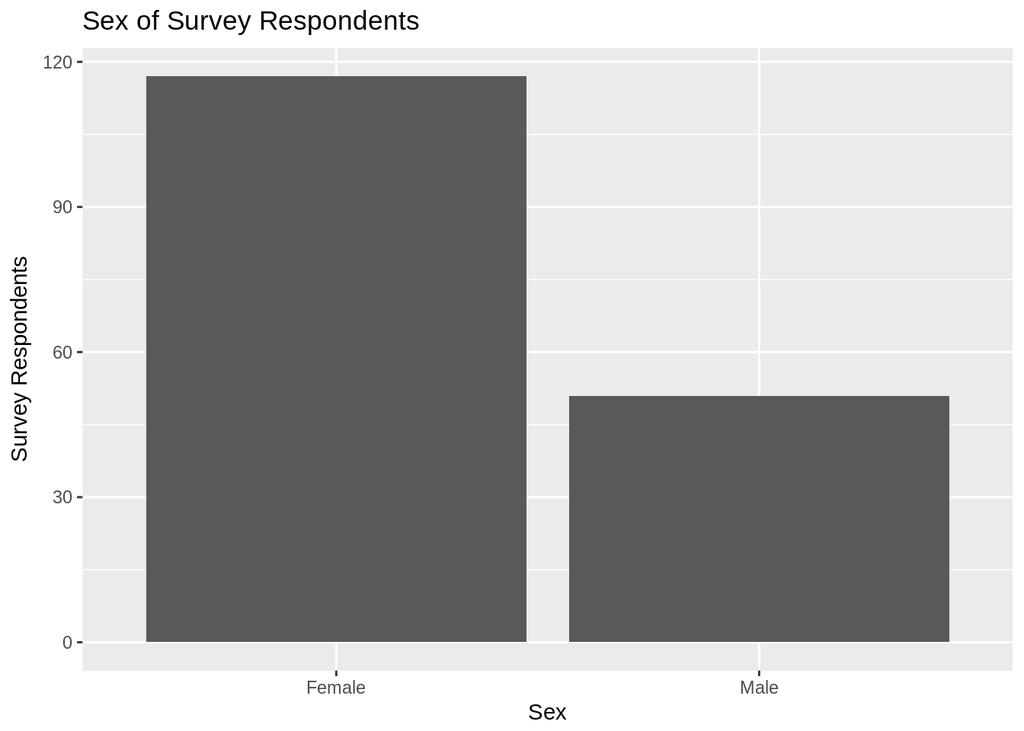

```r
people %>%
  ggplot(aes(x=sex))+geom_bar()+xlab("Sex")+ylab("Survey Respondents")+ggtitle("Sex of Survey Respondents")
```

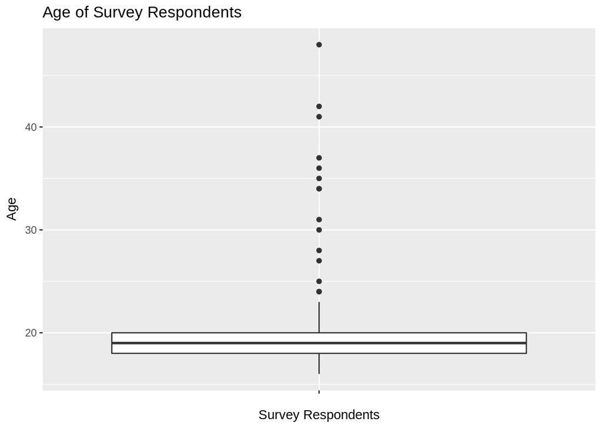

```r
people %>%
  ggplot(aes(x="",y=age))+geom_boxplot()+xlab("Survey Respondents")+ylab("Age")+ggtitle("Age of Survey Respondents")
```

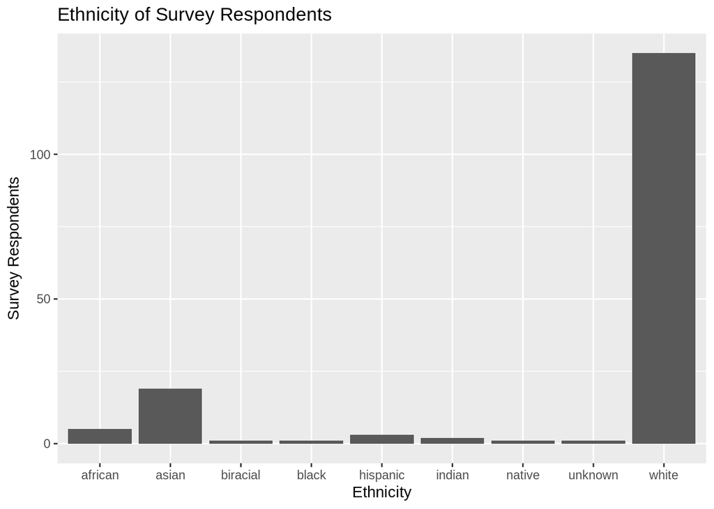

```r
people %>%
  ggplot(aes(x=ethnic))+geom_bar()+xlab("Ethnicity")+ylab("Survey Respondents")+ggtitle("Ethnicity of Survey Respondents")
```

**Familiar Words**

1. For each demographic group listed below, determine which word(s) in this study was the most and least familiar on average.
1. People below the age of 20

For people below 20 the most familiar word was “off the hook” and the least familiar word was “catch the vapors.”

```r
below20 <- hiphop %>%
  filter(age<20)%>%
  group_by(word)%>%
  summarize(avgFamiliarity=mean(familiarity))

below20%>%top_n(1,avgFamiliarity)
```

```
## # A tibble: 1 x 2
##   word         avgFamiliarity
##   <fctr>                <dbl>
## 1 off the hook           4.42
```

```r
below20%>%top_n(-1,avgFamiliarity)
```

```
## # A tibble: 1 x 2
##   word             avgFamiliarity
##   <fctr>                    <dbl>
## 1 catch the vapors           1.03
```

```r
noWhiteWoman <- newhiphop %>%
  filter(simpleEthnic == "non-white")%>%
  group_by(word)%>%
  summarize(avgFamiliarity=mean(familiarity))

noWhiteWoman%>%top_n(1,avgFamiliarity)
```

```
## # A tibble: 1 x 2
##   word    avgFamiliarity
##   <fctr>           <dbl>
## 1 feel me           4.21
```

```r
noWhiteWoman%>%top_n(-1,avgFamiliarity)
```

```
## # A tibble: 1 x 2
##   word       avgFamiliarity
##   <fctr>              <dbl>
## 1 The Nation           1.03
```

```r
whitemen30 <- hiphop %>%
  filter(age>20 & sex == "Male" & ethnic=="white")%>%
  group_by(word)%>%
  summarize(avgFamiliarity=mean(familiarity))

whitemen30%>%top_n(1,avgFamiliarity)
```

```
## # A tibble: 3 x 2
##   word         avgFamiliarity
##   <fctr>                <dbl>
## 1 5-0                    3.80
## 2 feel me                3.80
## 3 off the hook           3.80
```

```r
whitemen30%>%top_n(-1,avgFamiliarity)
```

```
## # A tibble: 15 x 2
##    word              avgFamiliarity
##    <fctr>                     <dbl>
##  1 ay yo trip                  1.00
##  2 beezy                       1.00
##  3 break someone out           1.00
##  4 crossroads                  1.00
##  5 dollar cab                  1.00
##  6 domino                      1.00
##  7 duckets                     1.00
##  8 fetti                       1.00
##  9 ghostride                   1.00
## 10 grip grain                  1.00
## 11 guap                        1.00
## 12 humming                     1.00
## 13 mail                        1.00
## 14 rollie                      1.00
## 15 saditty                     1.00
```

**Use the data**

A former Canadian child TV star named Aubrey Graham is interested in switching careers to become a rapper. Aubrey hires you to consult the hiphop dataset to help compose his new songs. Note: There is no single right answer to these questions. You will need to think about how you want to address the question, and do the appropriate variable adjustments and calculations to come up with a reasonable answer.

1. Aubrey hopes that his songs will be percieved as authentically hiphop. He hopes his lyrics will be recognizeable to those who describe themselves as hiphop fans, but less recognizeable to those who do not consider themselves fans. Suggest some words or phrases that Aubrey should try to use, and some words he should avoid.

The phrases “hella”, “what it do”, “boo”, “finna”, and “make it rain” are phrases that will be fairly recognizable to hip hop fans (who I have classified as those that like more than 2 hip hop artists), but not to those who are not (who I have classified as those that like 0 hip hop artists). I have created this list by first filtering out words that the people who aren’t hiphop fans generally recognize (average familiarity > 3.5) and then taking the top 5 words/phrases that have the greatest familiarity among those that listen to hiphop.

```r
 likeHiphop <- hiphop %>%
    filter(hiphop>2)%>%
    group_by(word)%>%
    summarize(avgHipFam=mean(familiarity))

  notHiphop <- hiphop %>%
    filter(hiphop==0)%>%
    group_by(word)%>%
    summarize(avgNoHipFam=mean(familiarity))

combined <- full_join(likeHiphop,notHiphop)
combined%>%arrange(desc(avgHipFam))%>%
  filter(avgNoHipFam<3.5)%>%top_n(5,avgHipFam)
```

```
## # A tibble: 5 x 3
##   word         avgHipFam avgNoHipFam
##   <fctr>           <dbl>       <dbl>
## 1 hella             4.23        3.43
## 2 what it do        3.70        2.43
## 3 boo               3.66        3.43
## 4 finna             3.45        1.69
## 5 make it rain      3.34        2.44
```

2. Although Aubrey wants to be authentic, he also hopes to sell records, of course. Two titles have been suggested for his first album: “Hotline Boo” or “Hella Bling”. Based on the dataset, which will appeal more to the higher population areas? Make at least one plot to support your answer.

I considered a person to be from a higher population area if either their city’s population was greater than 100000 (slightly less than the 3rd quartile for city population), or their county’s population was greater than 900000 ( about 59000 less than the the 3rd quartile for county population, but still fairly close to the the 3rd quartile). Then I only looked at the average familiarity for the words “boo” and “hella” and found “hella” to be the one with the greater average familiarity, which indicates more people would recognize and probably buy the album “Hella Bling”. So “Hella Bling” is the better option.

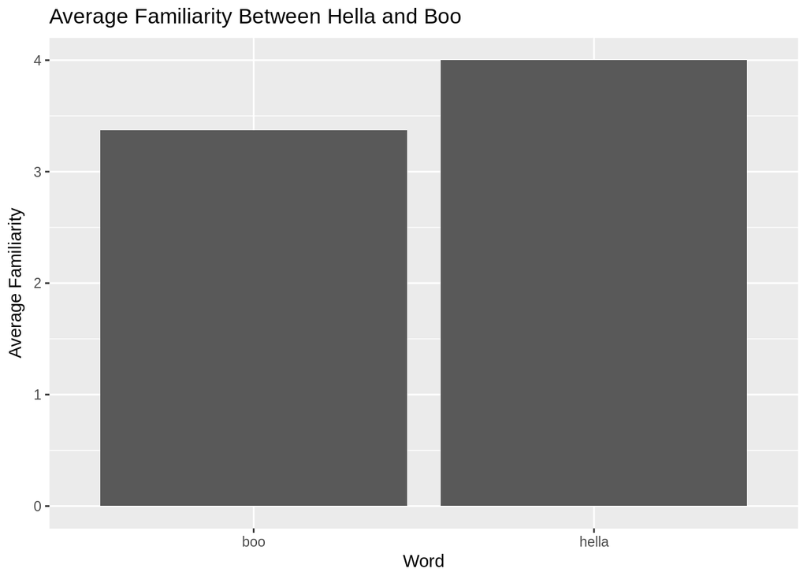

```r
betterAlbum <- hiphop %>%
  filter((city>100000|county>900000)&(word=="hella"|word=="boo"))%>%
  group_by(word) %>%
  summarize(avgFamiliarity=mean(familiarity))

betterAlbum%>%ggplot(aes(x=word, y=avgFamiliarity))+geom_col()+xlab("Word")+ylab("Average Familiarity")+ggtitle("Average Familiarity Between Hella and Boo")
```

3. Aubrey’s true life dream is to collaborate with his fellow Canadian musician Justin Bieber. Luckily, he knows that Bieber himself was one of the subjects in this study! You know that Bieber is a white male, aged 17-23 at the time of the study, from a relatively small town (10,000-60,000 people) in Ontario. Determine which subject is secretly Bieber, and justify your answer. Then suggest a track listing (11 song titles) for Aubrey’s album collaboration with the Biebs.

Seeing as how these are words are the AAE words the subject I presume to be Bieber is most familar with, I suggest the following track record:

1. **A-town**
2. My **Boo**
3. **Chedda** Baby
4. Falling **Duckets**
5. **Feel Me**
6. **Hard**
7. **Hella** Lit
8. **Off the Hook**
9. **Player Hater**
10. **Toe Up**
11. **What It Is?**

```r
JustinBieber <- hiphop %>%
  mutate( city = case_when(
                   city<=60000 ~ "small",
                   city>60000 & city<=100000 ~ "medium",
                   city>100000 ~ "large")
                          )%>%
  filter(bieber==5&sex=="Male"&ethnic=="white"&age>=17&age<=23&city=="small") %>%
  top_n(11,familiarity)%>%
  arrange(desc(familiarity))%>%
  select(word,familiarity)

JustinBieber
```

```
##            word familiarity
## 1        A-town           5
## 2           boo           5
## 3        chedda           5
## 4       duckets           5
## 5       feel me           5
## 6          hard           5
## 7         hella           5
## 8  off the hook           5
## 9  player hater           5
## 10       toe up           5
## 11  What it is?           5
```